**Non- Linear Modelling**

```r
library(ISLR)
attach(Wage)
```

**Polynomial Regression**

```r
poly.fit = lm(wage~poly(age,4), data=Wage)
coef(summary(poly.fit))
```

```
##                 Estimate Std. Error    t value     Pr(>|t|)
## (Intercept)    111.70361  0.7287409 153.283015 0.000000e+00
## poly(age, 4)1  447.06785 39.9147851  11.200558 1.484604e-28
## poly(age, 4)2 -478.31581 39.9147851 -11.983424 2.355831e-32
## poly(age, 4)3  125.52169 39.9147851   3.144742 1.678622e-03
## poly(age, 4)4  -77.91118 39.9147851  -1.951938 5.103865e-02
```

Above we are using orthogonal polynomials, which means that each term of polynomial is linear combination of variables age, age^2, age^3, age^4. so we are testing each of coefficient seperately. We can decide seperately for each term if that is needed or not.

we can use also use raw polynomials by:

```r
poly.fit2 = lm(wage~poly(age,4,raw=T), data= Wage)
coef(summary(poly.fit2))
```

```
##                             Estimate   Std. Error   t value     Pr(>|t|)
## (Intercept)            -1.841542e+02 6.004038e+01 -3.067172 0.0021802539
## poly(age, 4, raw = T)1  2.124552e+01 5.886748e+00  3.609042 0.0003123618
## poly(age, 4, raw = T)2 -5.638593e-01 2.061083e-01 -2.735743 0.0062606446
## poly(age, 4, raw = T)3  6.810688e-03 3.065931e-03  2.221409 0.0263977518
## poly(age, 4, raw = T)4 -3.203830e-05 1.641359e-05 -1.951938 0.0510386498
```

Choice of type of polynomial does not affect fitted values obtained but it affects coefficient estimate as seen.

we can fit polynomial regression by:

```r
poly.fit3 = lm(wage~age+I(age^2)+I(age^3)+I(age^4), data=Wage)
coef(poly.fit3)
```

```
##   (Intercept)           age      I(age^2)      I(age^3)      I(age^4)
## -1.841542e+02  2.124552e+01 -5.638593e-01  6.810688e-03 -3.203830e-05
```

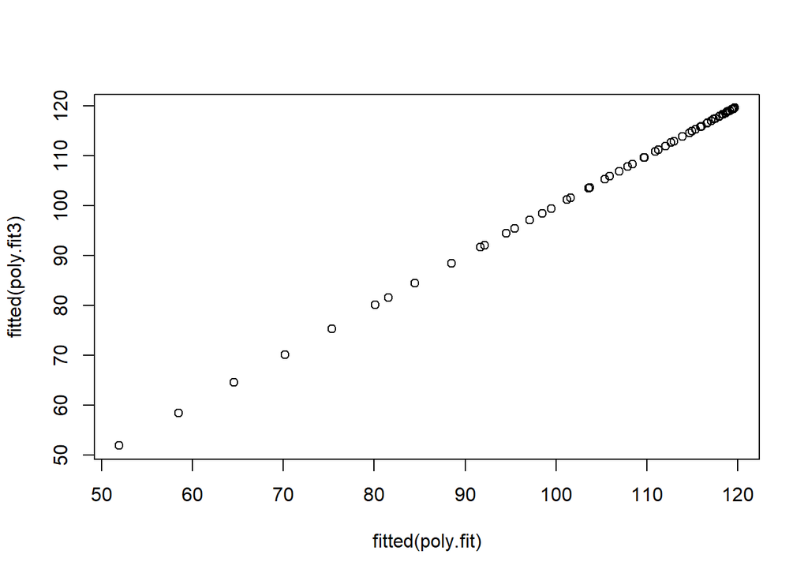

```r
plot(fitted(poly.fit), fitted(poly.fit3))
```

Perfect straight line proves that there is no change in fitted values even if the coefficients have different values duw to nature of polynomial.(Orthogonal or Raw)

we will now create grid of values of `age` for which we want predictions.

```r
age.grid = seq(from=range(age)[1], to=range(age)[2])
```

above function will generate grid of 63 age variables from 18 to 80.

```r
preds = predict(poly.fit,newdata=list(age=age.grid), se=TRUE)
se.bands = cbind(preds$fit+2*preds$se.fit,preds$fit-2*preds$se.fit)
```

```r
par(mfrow=c(1,2),mar=c(4.5,4.5,1,1), oma=c(0,0,4,0))
```

As we can see there are 2 margins. `mar` argument is used to set margins and `oma` to set outer margins.

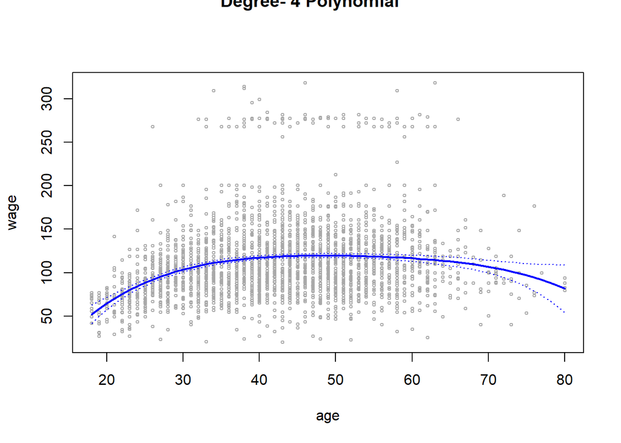

```r
plot(age,wage,xlim=range(age),cex=0.5, col="darkgrey")
title("Degree- 4 Polynomial", outer=T)
lines(age.grid,preds$fit,lwd=2, col="blue")
matlines(age.grid,se.bands, lwd=1, col="blue",lty=3)
```

```r
preds2 = predict(poly.fit2, newdata=list(age=age.grid), se=TRUE)
max(abs(preds$fit-preds2$fit))
```

```
## [1] 7.81597e-11
```

Above quantity suggests that there is very minimal changes is prediction between orthogonal and raw polynomials.

For determing degree of polynomial, we can use hypothesis tests.

We will use the `anova()` function which performs analysis of variance (ANOVA using an F-test) in order to test null hypothesis that a model M<sub>1</sub> is sufficient to explain the data against the alternative hypothesis that a more complex model M<sub>2</sub> is required.

In order to use `anova()` function, M<sub>1</sub> and M<sub>2</sub> must be nested models i.e. all of predictors in M<sub>1</sub> must be a subset of predictors in M<sub>2</sub>.

```r
fit = lm(wage~education, data=Wage)
fit.1 = lm(wage~age, data=Wage)
fit.2 = lm(wage~poly(age,2), data=Wage)
fit.3 = lm(wage~poly(age,3), data=Wage)
fit.4 = lm(wage~poly(age,4), data=Wage)
fit.5 = lm(wage~poly(age,5), data=Wage)
```

using `anova()` function:

```r
anova(fit,fit.1,fit.2,fit.3,fit.4,fit.5)
```

```
## Analysis of Variance Table
##
## Model 1: wage ~ education
## Model 2: wage ~ age
## Model 3: wage ~ poly(age, 2)
## Model 4: wage ~ poly(age, 3)
## Model 5: wage ~ poly(age, 4)
## Model 6: wage ~ poly(age, 5)
##   Res.Df     RSS Df Sum of Sq        F    Pr(>F)
## 1   2995 3995721
## 2   2998 5022216 -3  -1026495 214.7532 < 2.2e-16 ***
## 3   2997 4793430  1    228786 143.5931 < 2.2e-16 ***
## 4   2996 4777674  1     15756   9.8888  0.001679 **
## 5   2995 4771604  1      6070   3.8098  0.051046 .
## 6   2994 4770322  1      1283   0.8050  0.369682
## ---
## Signif. codes:  0 '***' 0.001 '**' 0.01 '*' 0.05 '.' 0.1 ' ' 1
```

we can also obtain P- values briefly by using fact that `poly()` creates orthogonal polynomials.

```r
coef(summary(fit.5))
```

```
##                 Estimate Std. Error     t value     Pr(>|t|)
## (Intercept)    111.70361  0.7287647 153.2780243 0.000000e+00
## poly(age, 5)1  447.06785 39.9160847  11.2001930 1.491111e-28
## poly(age, 5)2 -478.31581 39.9160847 -11.9830341 2.367734e-32
## poly(age, 5)3  125.52169 39.9160847   3.1446392 1.679213e-03
## poly(age, 5)4  -77.91118 39.9160847  -1.9518743 5.104623e-02
## poly(age, 5)5  -35.81289 39.9160847  -0.8972045 3.696820e-01
```

We can also use `anova()` method with or without polynomial, it also works when we have other terms in model

```r
fit.1 = lm(wage~education+age, data= Wage)
fit.2 = lm(wage~education+poly(age,2), data= Wage)
fit.3 = lm(wage~education+poly(age,3), data= Wage)
anova(fit.1,fit.2,fit.3)
```

```
## Analysis of Variance Table
##
## Model 1: wage ~ education + age
## Model 2: wage ~ education + poly(age, 2)
## Model 3: wage ~ education + poly(age, 3)
##   Res.Df     RSS Df Sum of Sq        F Pr(>F)
## 1   2994 3867992
## 2   2993 3725395  1    142597 114.6969 <2e-16 ***
## 3   2992 3719809  1      5587   4.4936 0.0341 *
## ---
## Signif. codes:  0 '***' 0.001 '**' 0.01 '*' 0.05 '.' 0.1 ' ' 1
```

We can also choose polynomial using degree validation.

**Polynomial Logistic Regression**

We will now predict whether an individual ears more than $250,000 per year.

```r
fit = glm(I(wage>250)~poly(age,3), data= Wage, family = binomial)
summary(fit)
```

```
##
## Call:
## glm(formula = I(wage > 250) ~ poly(age, 3), family = binomial,
##     data = Wage)
##
## Deviance Residuals:
##     Min       1Q   Median       3Q      Max
## -0.2808  -0.2736  -0.2487  -0.1758   3.2868
##
## Coefficients:
##               Estimate Std. Error z value Pr(>|z|)
## (Intercept)    -3.8486     0.1597 -24.100  < 2e-16 ***
## poly(age, 3)1  37.8846    11.4818   3.300 0.000968 ***
## poly(age, 3)2 -29.5129    10.5626  -2.794 0.005205 **
## poly(age, 3)3   9.7966     8.9990   1.089 0.276317
## ---
## Signif. codes:  0 '***' 0.001 '**' 0.01 '*' 0.05 '.' 0.1 ' ' 1
##
## (Dispersion parameter for binomial family taken to be 1)
##
##     Null deviance: 730.53  on 2999  degrees of freedom
## Residual deviance: 707.92  on 2996  degrees of freedom
## AIC: 715.92
##
## Number of Fisher Scoring iterations: 8
```

we use wrapper `I()` to create binary response.

```r
preds = predict(fit, newdata=list(age=age.grid), se=TRUE)
```

to calculate standard error bands:

```r
se.bands = preds$fit + cbind(fit=0, lower=-2*preds$se, upper=2*preds$se)
```

`cbind(fit=0, lower=-2*preds$se, upper=2*preds$se)` will be a 3 column matrix and preds$fit will be added to ech of the columns.

```r
se.bands[1:5,]
```

```
##         fit      lower     upper
## 1 -7.664756 -10.759826 -4.569686
## 2 -7.324776 -10.106699 -4.542852
## 3 -7.001732  -9.492821 -4.510643
## 4 -6.695229  -8.917158 -4.473300
## 5 -6.404868  -8.378691 -4.431045
```

We have done computation on logit scale, to transform we need to apply inverse logit to get it on probability scale.

$$p=\frac{e^\eta}{1+ e^\eta}$$

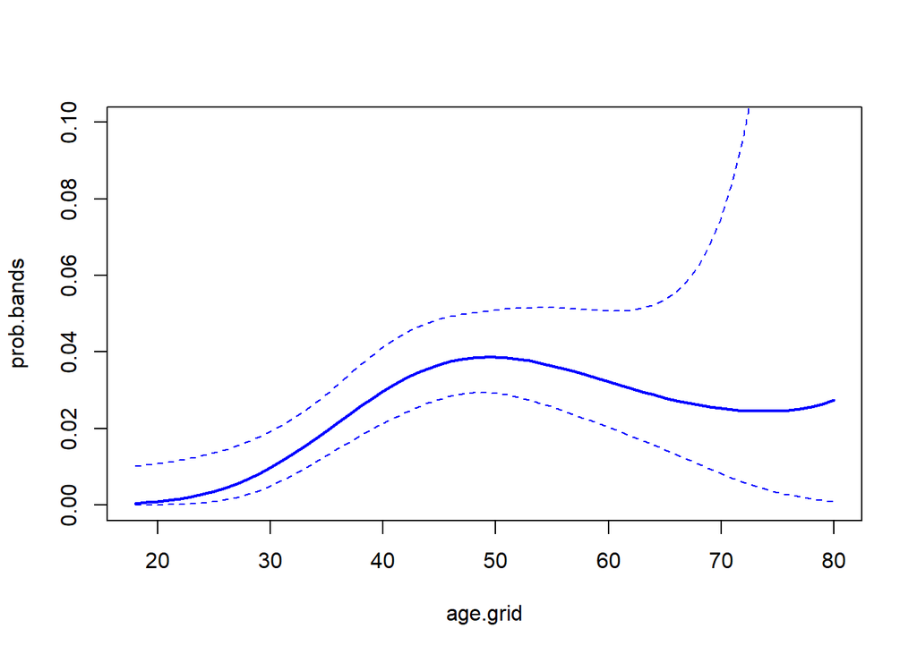

```r
prob.bands = exp(se.bands)/(1+exp(se.bands))
matplot(age.grid,prob.bands, col="blue", lwd=c(2,1,1), lty=c(1,2,2), type="l", ylim=c(0,0.1))
```

We will now add data points to plot.

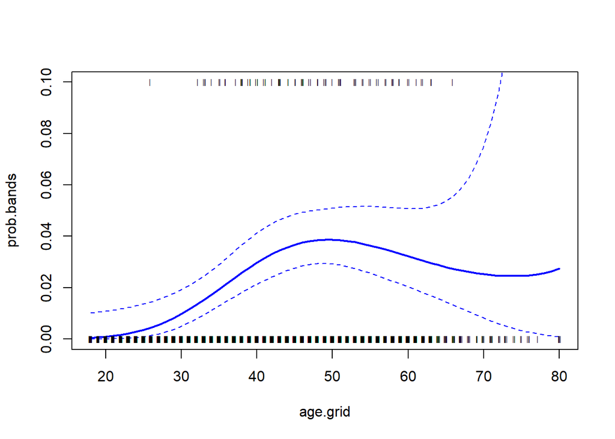

```r
prob.bands = exp(se.bands)/(1+exp(se.bands))
matplot(age.grid,prob.bands, col="blue", lwd=c(2,1,1), lty=c(1,2,2), type="l", ylim=c(0,0.1))
points(jitter(age),I(wage>250)/10, pch="|", cex=0.5)
```

**Splines**

Cubic Splines:

```r
require(splines)
```

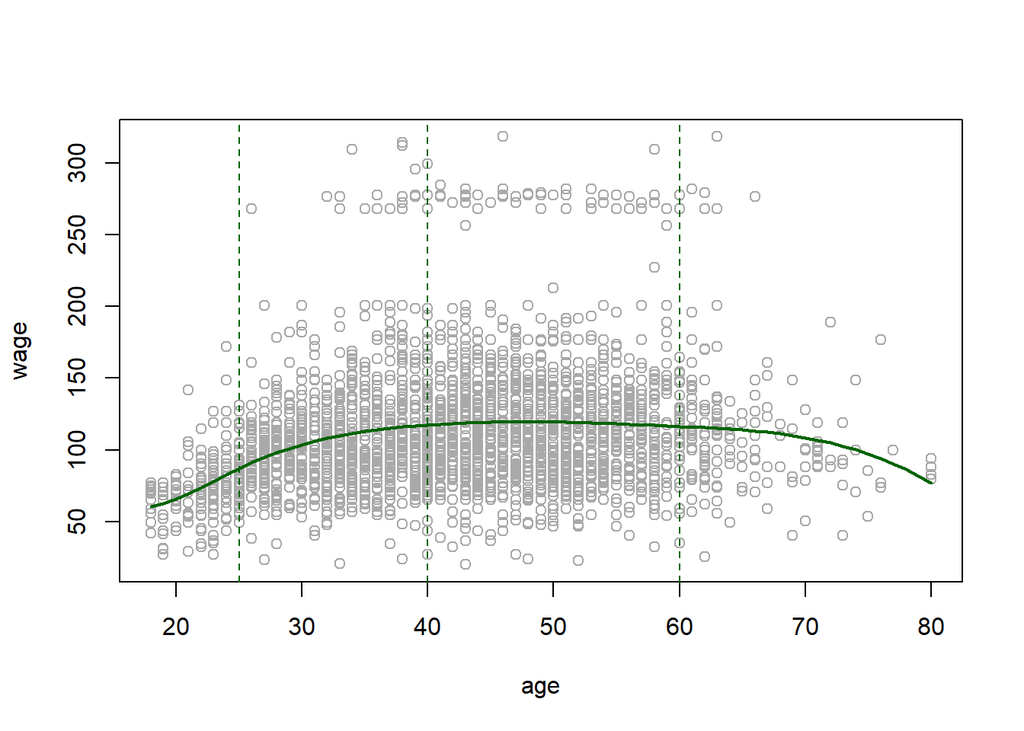

```r
fit = lm(wage~bs(age, knots=c(25,40,60)), data=Wage)
plot(age,wage, col="darkgrey")
lines(age.grid, predict(fit, newdata=list(age=age.grid)), col="darkgreen", lwd=2)
abline(v=c(25,40,60), lty=2, col="darkgreen")
```

Smoothing Splines

smoothing splines do not require knot selection , but it has a tuning parameter. Tuning parameter can be specified by effective degrees of freedom(`df`)

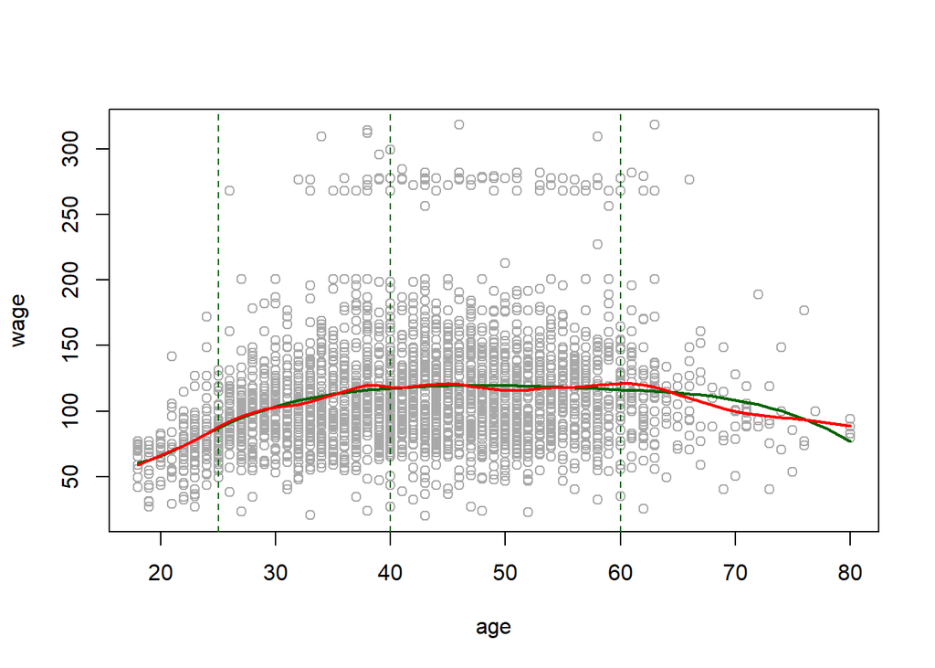

```r
fit1 = smooth.spline(age, wage, df=16)
plot(age,wage, col="darkgrey")
lines(age.grid, predict(fit, newdata=list(age=age.grid)), col="darkgreen", lwd=2)
abline(v=c(25,40,60), lty=2, col="darkgreen")
lines(fit1,col="red", lwd=2)
```

We can also use LOOCV(Leave one out cross validation) to select the smoothing parameter effectively.

```r
fit2 = smooth.spline(age,wage, cv=TRUE)
```

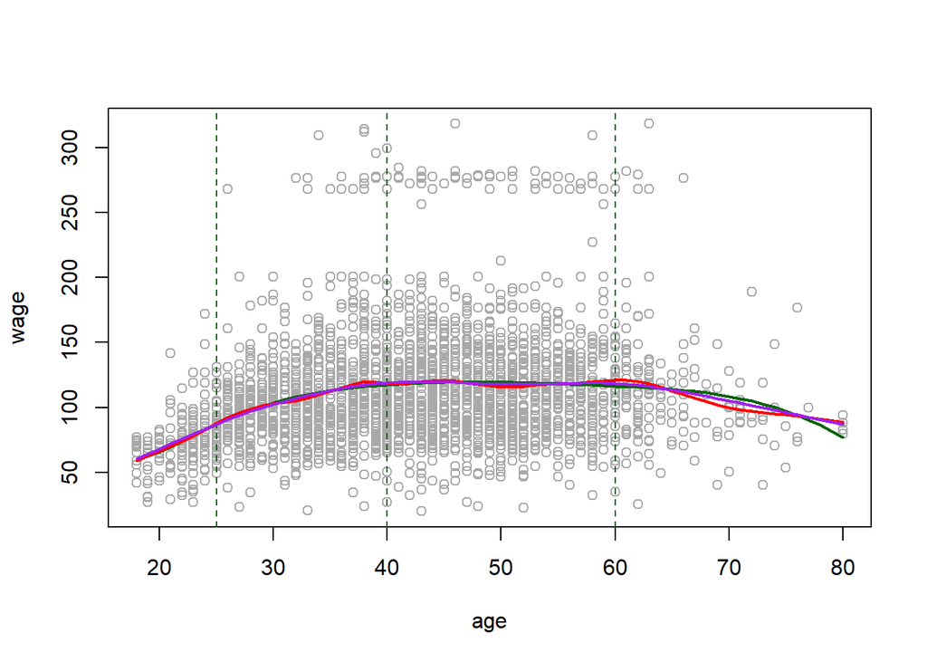

```r
plot(age,wage, col="darkgrey")
lines(age.grid, predict(fit, newdata=list(age=age.grid)), col="darkgreen", lwd=2)
abline(v=c(25,40,60), lty=2, col="darkgreen")
lines(fit1,col="red", lwd=2)
lines(fit2, col="purple", lwd=2)
```

```r
fit2
```

```
## Call:
## smooth.spline(x = age, y = wage, cv = TRUE)
##
## Smoothing Parameter  spar= 0.6988943  lambda= 0.02792303 (12 iterations)
## Equivalent Degrees of Freedom (Df): 6.794596
## Penalized Criterion (RSS): 75215.9
## PRESS(l.o.o. CV): 1593.383
```

**Generalized Additive Models:**

```r
library(gam)
gam1 = gam(wage~s(age,df=4)+s(year, df=4)+ education, data=Wage)
```

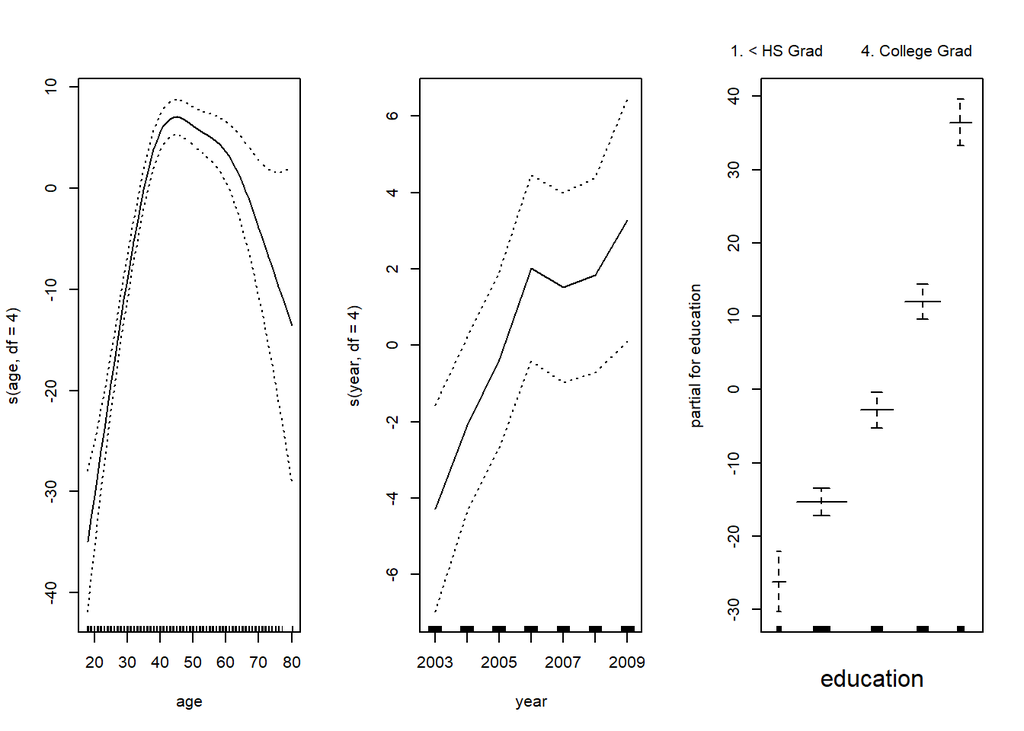

```r
par(mfrow=c(1,3))
plot(gam1, se=TRUE)
```

Using GAM for logistic regression:

```r
gam2 = gam(I(wage>250)~s(age,df=4)+s(year,df=4)+education, family=binomial)
```

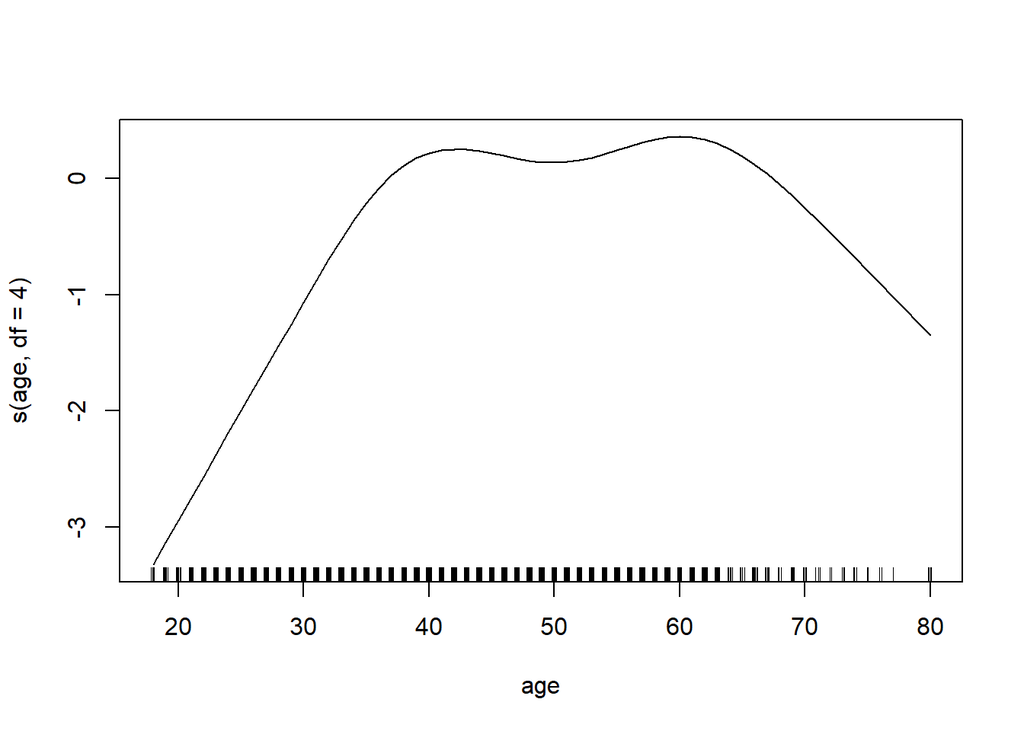

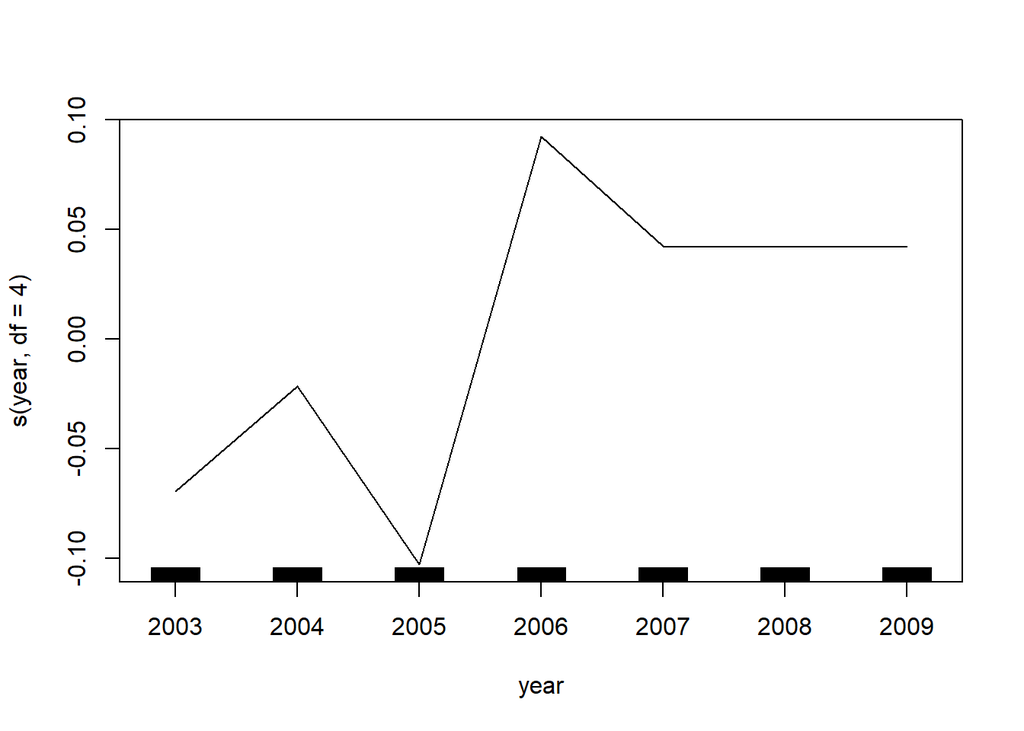

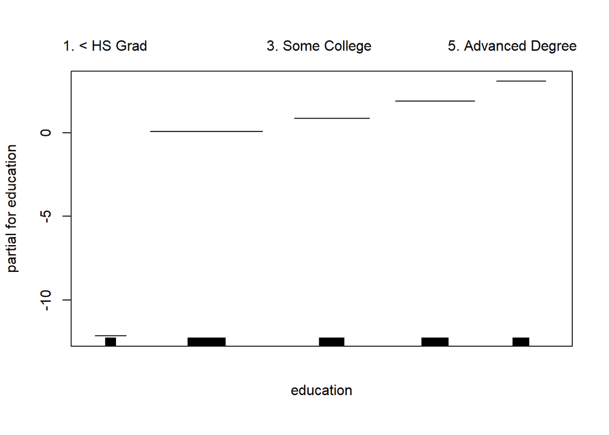

```r
plot(gam2)
```

If we want to add a non-linear terms for year:

```r
gam2a = gam(I(wage>250)~s(age,df=4)+year+education, data=Wage, family=binomial)
anova(gam2a,gam2,test="Chisq")
```

```
## Analysis of Deviance Table
##
## Model 1: I(wage > 250) ~ s(age, df = 4) + year + education
## Model 2: I(wage > 250) ~ s(age, df = 4) + s(year, df = 4) + education
##   Resid. Df Resid. Dev Df Deviance Pr(>Chi)
## 1      2990     603.78
## 2      2987     602.87  3  0.90498   0.8242
```

P- value of 0.82 indicate that we do not need non-linear term for year.